# DA3 -A2- Technical Report

# Introduction

This analysis will focus on predicting the price of airbnb apartments in Porto to help a company price their new apartments. These apartments accommodate between 2 to 6 people. Different prediction models of varying complexity will be analyzed and compared. OLS Linear Regressions, Lasso Regression, CART algorithm, Random forest and GBM will be used to gauge the better predictions.

# Sample Design and Feature Engineering

The initial data contained 10747 observations, which contained the price for the Airbnb apartments for 9th December 2021. The price per day was maintained in Euros. The distribution of the daily price was strongly skewed and the distribution of its log was close to normally distributed.The summary and visuals can be seen below.

|  | Mean | Median | Min | Max | P25 | P75 | P95 |
| --- | --- | --- | --- | --- | --- | --- | --- |
| eur_price_day | 66.45 | 57.00 | 9.00 | 999.00 | 40.00 | 78.00 | 130.00 |

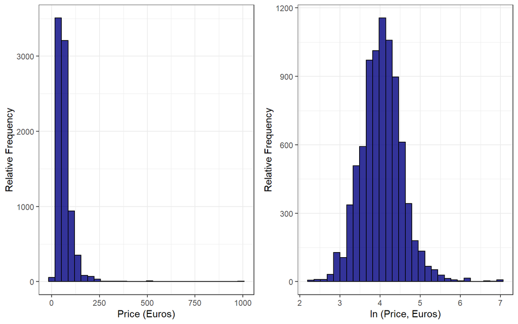

In this case however, we will proceed with taking level price for clearer interpretability of the results.

As far as predictor variables were concerned, the intuitively more important ones included property type, room type, neighbourhood, along with numerical variables containing information regarding the number of beds, bedrooms and bathrooms. Furthermore, review-based columns pertaining to the number of reviews, reviews per month and the review scores based on criterion such as cleanliness, location etc were also included.

For interactions, conditional distributions of price were looked at based on different values for the categorical variables. Some interactions were included for the neighbourhood variables based on domain knowledge via external research. As can be seen from the distributions below, different price patterns can be observed for different categories based on variations in other predictor variables.

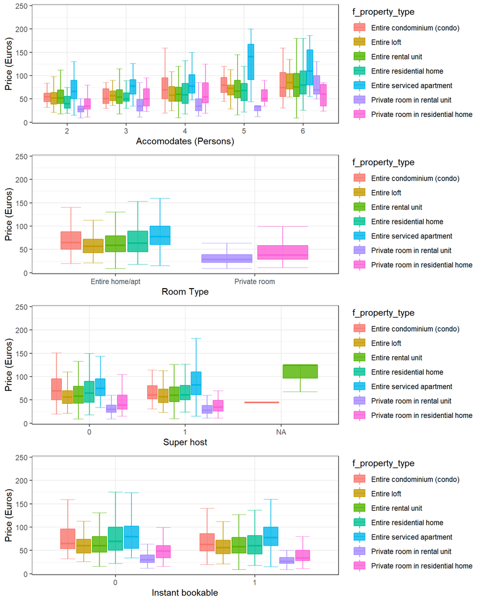

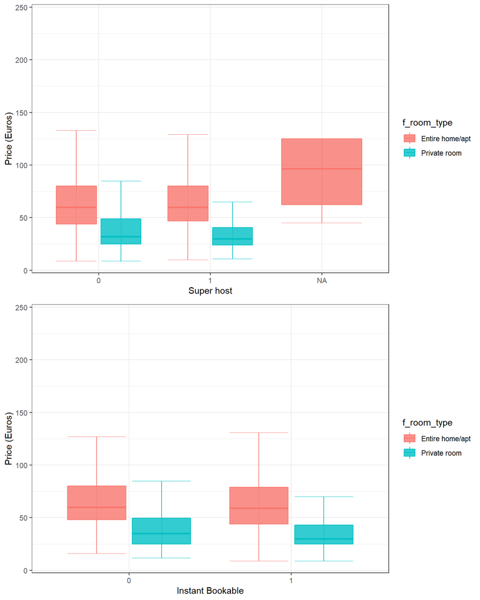

# Model Building

Three regression models were specified for the prediction analysis. The three models differed in terms of model complexity (based on the number of variables) where the first model contained the key predictor variables. The second contained the review-based variables as well as the binary variables in addition to the basic key predictors. For the last, most complex model, interaction terms of the neighbourhood with property and room type along with number of people accommodated were added. These regression models can be seen below:

Models on which algorithms will be run

| Model | Predictor Variables |
| --- | --- |
| M1 | = Number of guests accommodated (squared term also), number of beds (squared term also), number of bedrooms (squared term also), Days since first review (squared and cubic also), Neighbourhood, Minimu… |
| M2 | = m1 + log of all review based columns + relevant amenities |
| M3 | = m2 + selected interaction terms with prop type and room type + interaction terms with neighbourhoods |

We looked at patterns of association between the numerical predictor variables and the target variable. It was found that the price is approximately linearly related to the number of people that the apartment can accommodate. However, due to a slightly non-linear trend for higher values of this predictor variable, it was specified as a quadratic. Parabolas were observed for the number of beds, bedrooms and the days since the first review. These were modelled as quadratics as well. For review-linked variables, non-linear trends were observed for which their logarithms were included. A summary of the trends observed can be seen below:

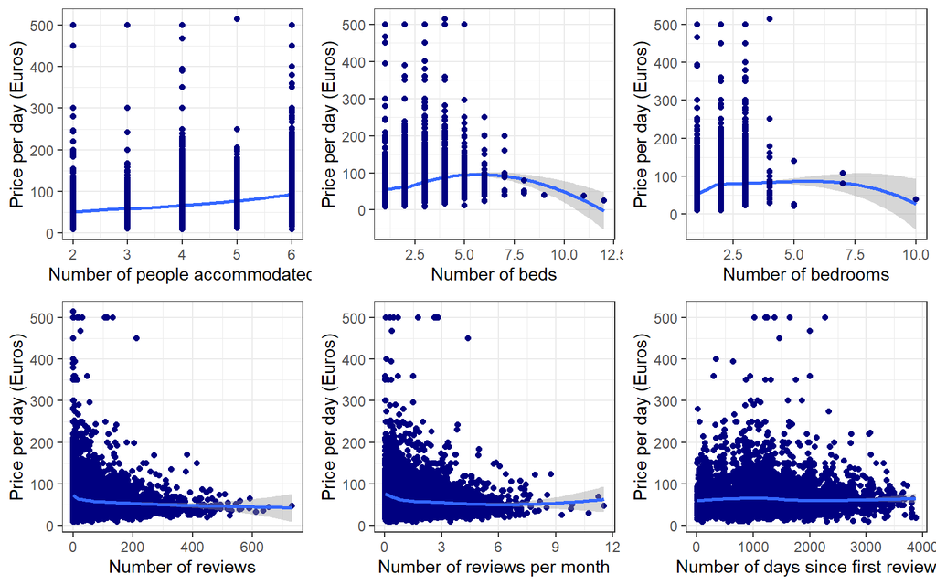

For model training and testing, the sample was divided into two sub-samples, namely the work sample and the holdout sample. The work sample contained 70% of randomly selected observations from the initial sample whereas 30% were kept in the holdout set. 5-fold cross validation was done on the work set, where 5 further random splits were made (after replacement)for the training set and test usage. The code snippet for this process can be seen below. Because of the sample design dilemma, two sets of train and holdout sets were created. Similarly, two sets of basic variables and review-based variables were created. In the dataset with imputed values, additional flag variables were created. Based on domain knowledge, as well as the exploratory analysis done above for interactions, sets of interactions were created to be included in the more complex models. The set X3 was created to interact the binary flag variable with other key variables in case that was the dataset which produces the better prediction.

```r
set.seed(2801)
train_indices <- as.integer(createDataPartition(df$eur_price_day, p = 0.7,
                                                list = FALSE))
data_train <- df[train_indices, ]
data_holdout <- df[-train_indices, ]

train_indices2 <- as.integer(createDataPartition(df_new$eur_price_day, p = 0.7,
                                                 list = FALSE))
data_train2 <- df_new[train_indices2, ]
data_holdout2 <- df_new[-train_indices2, ]

# Basic Variables inc neighbourhood - df
basic_vars <- c(
  "n_accommodates","n_accommodates2", "beds2","bedrooms2","n_beds","n_bedrooms",

  "n_days_since","f_property_type","f_room_type", "n_bathroom","n_bedrooms",
  "n_minimum_nights",
  "f_neighbourhood_cleansed","flag_days_since","n_days_since2","n_days_since3")

# Basic Variables inc neighbourhood - df_new
basic_vars2 <- c(
  "n_accommodates","n_accommodates2","n_beds","n_bedrooms","beds2","bedrooms2",
  "n_days_since","f_property_type","f_room_type", "n_bathroom",
  "n_minimum_nights","f_neighbourhood_cleansed","n_days_since2","n_days_since3")

# reviews - df
reviews <- c("flag_reviews_combined" ,
             "ln_number_of_reviews", "ln_reviews_per_month",
             "ln_review_scores_rating","ln_review_scores_accuracy",
             "ln_review_scores_cleanliness",
             "ln_review_scores_checkin","ln_review_scores_communication",
             "ln_review_scores_location",
             "ln_review_scores_value","flag_review_scores_rating")

# reviews - df_new
reviews2 <- c("ln_review_scores_rating","ln_review_scores_accuracy",
              "ln_number_of_reviews","ln_reviews_per_month",
             "ln_review_scores_cleanliness","n_review_scores_checkin",
             "ln_review_scores_communication","n_review_scores_location",
             "ln_review_scores_value")

# Dummy variables
binaries <-  grep("^d_.*", names(df), value = TRUE)

#interactions for the LASSO

X1  <- c("n_accommodates*f_property_type",  "f_room_type*f_property_type",
         "f_room_type*d_superhost","d_superhost*f_property_type",
         "d_instant_bookable*f_room_type", "d_instant_bookable*f_property_type")

# interacting with neighborhoods

X2  <- c("f_property_type*f_neighbourhood_cleansed",
         "f_room_type*f_neighbourhood_cleansed",
         "n_accommodates*f_neighbourhood_cleansed" )

# interacting with combined flag

X3  <- c("flag_reviews_combined*f_property_type",
         "flag_reviews_combined*f_room_type",
         "flag_reviews_combined*f_neighbourhood_cleansed",
         "flag_reviews_combined*n_accommodates",
         "flag_reviews_combined*n_review_scores_rating",
         "flag_reviews_combined*n_reviews_per_month")


predictors_1 <- c(basic_vars)
predictors_2 <- c(basic_vars, reviews, binaries)
predictors_E <- c(basic_vars2, reviews2, binaries, X1,X2)

predictors_1_new <- c(basic_vars2)
predictors_2_new <- c(basic_vars2, reviews2, binaries)
```

# Model Evaluation

## Random forest

Because of the ‘blackbox’ nature of the algorithm, model diagnostics were performed to identify some of the most important variables in RMSE reduction. To get a clearer picture, the top 10 RMSE reducers were visualized and the results can be seen below. Many of the review-based variables along with the number of bedrooms were considerably important variables in improving the fit of the predictions.

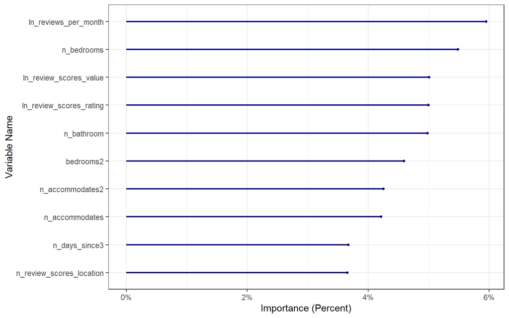

In the case of grouped variables, it turns out that neighbourhood cleansed is the most important in improving the model fit. Property type, number of variables (discrete factored) and the number of people the apartment can accommodate turned out to be key grouped variables which are considerably important in improving the fit of the prediction.

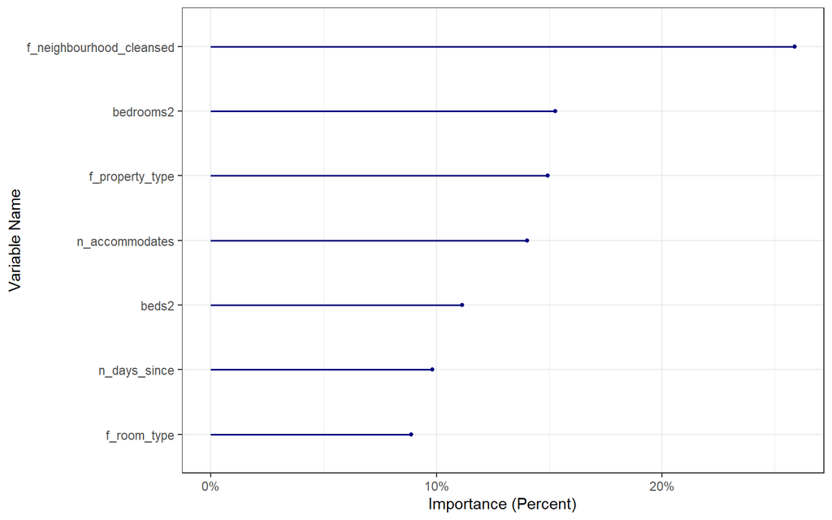

Next, a couple of these top variables were explored by examining their impact on the target variable conditioned on other variables. It can indeed be verified that variation in these variables tends to impact the expected price by quite a fair amount.

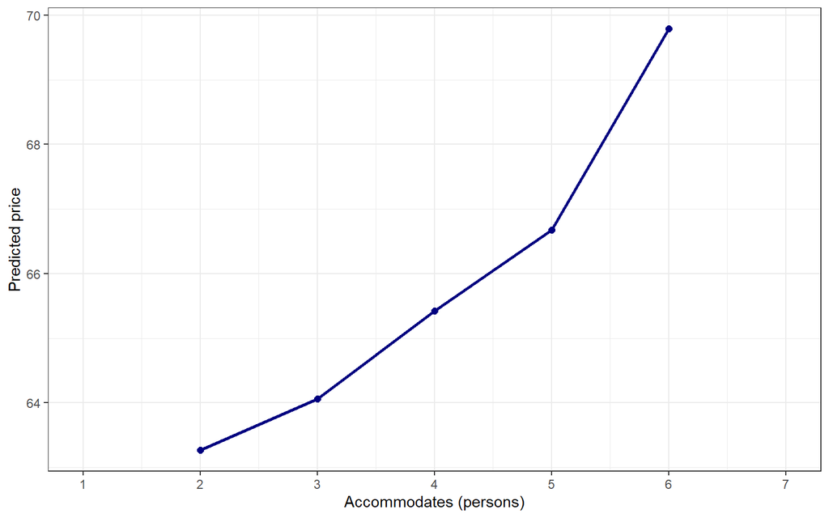

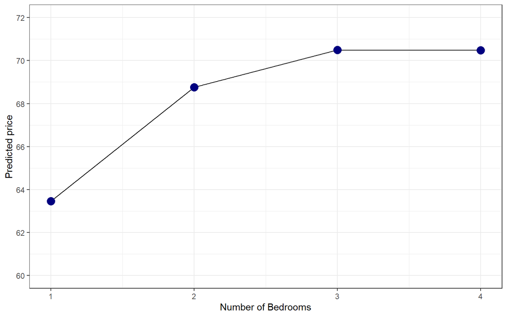

**Sub-Sample Diagnostics**

| Var.1 | RMSE | Mean.price | RMSE.price |
| --- | --- | --- | --- |
| Apartment size | NA | NA | NA |
| large apt | 54.35209 | 73.95301 | 0.7349544 |
| small apt | 45.91943 | 53.81087 | 0.8533487 |
| Type | NA | NA | NA |
| Entire condominium (condo) | 38.39577 | 75.89130 | 0.5059311 |
| Entire loft | 28.91702 | 63.18182 | 0.4576794 |
| Entire rental unit | 56.77346 | 68.01630 | 0.8347037 |
| Entire residential home | 37.45089 | 76.42446 | 0.4900380 |
| Entire serviced apartment | 30.30179 | 85.17647 | 0.3557531 |
| Private room in rental unit | 17.45825 | 31.08553 | 0.5616198 |
| Private room in residential home | 15.64974 | 37.25000 | 0.4201272 |
| Borough | NA | NA | NA |
| Lordelo do Ouro e Massarelos | 57.21347 | 73.88462 | 0.7743624 |
| Mafamude e Vilar do Paraíso | 107.18932 | 64.00000 | 1.6748332 |
| Matosinhos e Leça da Palmeira | 21.45587 | 59.51064 | 0.3605385 |
| Santa Marinha e São Pedro da Afurada | 35.33879 | 65.91071 | 0.5361615 |
| All | 50.80599 | 65.07005 | 0.7807892 |

Finally, the extended rf model was examined using sub-samples pertaining to three variables, namely, the number of people the apartment size (based on n_accommodates), the property type and the neighbourhoods. The neighbourhoods were selected randomly from their appearance on the full variable importance plot. It can be seen that predicting the price for smaller apartments is harder than bigger ones. Similarly, entire rental units have a much higher RMSE:price ratio, and hence are harder to predict than all other property types. Lastly, the neighbourhood, ‘Mafamude e Vilar do Paraíso’ had substantially higher RMSE:price ratio and is much harder to predict than other neighbourhoods.

## OLS and Lasso

OLS linear regression was run on model 2. It was run with a 5-fold CV. 159 variables were used in this case. Similarly, for LASSO, the most complex model (model 3) was used, which had the highest complexity, in terms of the number of variables as well as the functional forms assigned. This algorithm was also run with a 5-fold cross validation for selecting the optimal value of lambda. In the end, the algorithm picked a model with 218 variables. An overlap is observed between the LASSO coefficients and the OLS coefficients, and the values are also not too different. However, different variable and functional form selection is also seen in the case of LASSO.

## CART and GBM

In the case of the CART algorithm, resampling results were obtained for 10 values of the complexity parameter (in the order of increasingly stricter stopping rules). RMSE was the metric that was chosen to obtain the optimal model out of the 10 samples. The final value used for the model was with the complexity parameter equal to 0.0157, indicating that the stopping rule for the splitting would be where the R-squared in the test sample would increase by less than 1.57%. The regression tree indicates that splitting the data based on the number of bedrooms improves the model fit and reduces the RMSE the most.Similarly, the next split is done on the basis on the roomtype category ‘Private room’. To avoid overfitting of the regression tree, pruning of the tree has been added as an input in the model setup.

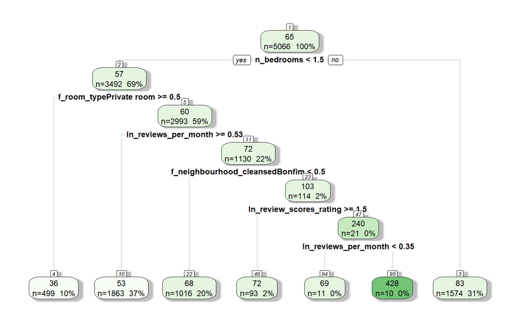

Lastly, GBM was used for the final model, which is similar to random forest, except that instead of growing independent trees, it grows trees which build on each other, and then they are combined to make a prediction. Multiple tuning parameters had to be specified in this case. The tree complexity was set at 5 and the number of trees made were kept at 250. The learning rate was specified at 0.1 and the minimum samples were 20.

Horse Race of Models CV RSME

|  | CV RMSE |
| --- | --- |
| OLS | 48.54922 |
| LASSO (model w/ interactions) | 47.97784 |
| CART | 49.98323 |
| Random forest 1: smaller model | 48.56969 |
| Random forest 2: extended model | 47.50522 |
| GBM | 48.24007 |

# Conclusion

Holdout set RSME of models

|  | Holdout RMSE |
| --- | --- |
| OLS | 51.69273 |
| LASSO (model w/ interactions) | 51.47251 |
| CART | 50.75604 |
| Random forest 1: smaller model | 51.81843 |
| Random forest 2: extended model | 50.80599 |
| GBM | 49.76036 |